# White Wine Exploration by Mohammad Albloushi

### Total Sulfur Dioxide x Density

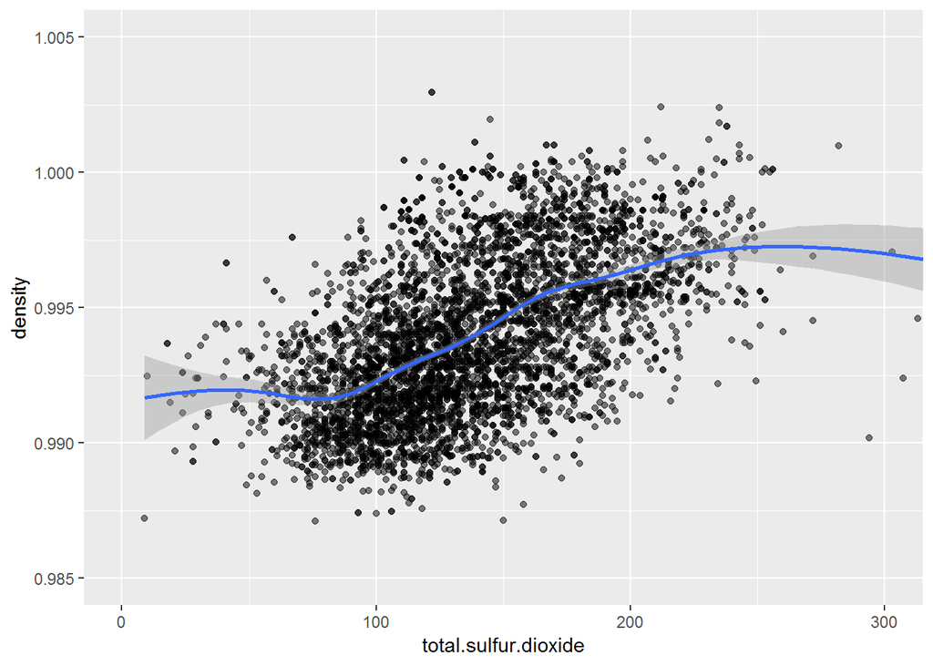

Here have an odd positive relationship here, we can see in our line that it start’s with a smooth straight line, and then it goes up around 100 **Total Sulfur Dioxide** and stops around 200 with another smooth straight line.

### Alcohol x Residual Sugar

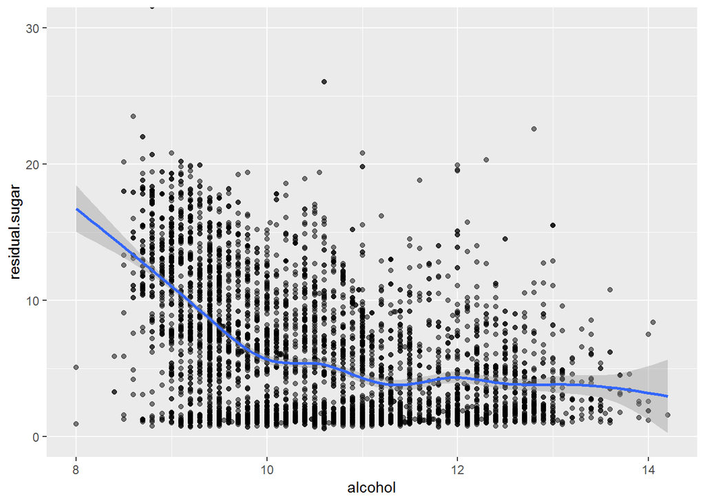

**Alcohol** and **Sugar** have a negative relationship, We can see when **Alcohol** increases the **Residual Sugar** decrease but not by much.

# Bivariate Analysis

### Talk about some of the relationships you observed in this part of the investigation. How did the feature(s) of interest vary with other features in the dataset?

I Analyzed **Quality** with each Variable, **Alcohol** Had the strongest correlation with **Quality** And in the boxplot it showed us that **Alcohol** have an effect on the **Quality** of wine, Followed up by **Density** with the strongest negative correlation which showed us having a lower **Density** may lead to better **Quality**, What is interesting that the correlation between **Alcohol** and **Density** is the strongest negative correlation in the entire matrix.

### Did you observe any interesting relationships between the other features (not the main feature(s) of interest)?

**Density** has the strongest positive and negative correlation in the matrix, The strongest positive correlation is with **Residual Sugar** And the strongest negative correlation is with **Alcohol**, Also **Density** have a lot more strong correlations.

### What was the strongest relationship you found?

The strongest relationship is between **Density** and **Residual Sugar**.

# Multivariate Plots Section

### Residual Sugar x Density x Rating

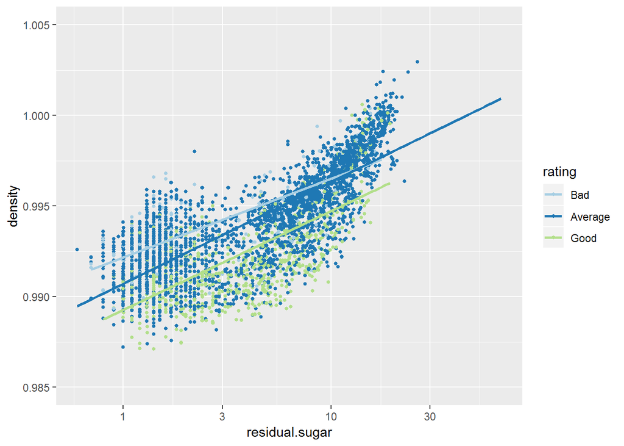

In this plot I can see that most of the good **Quality** wines have **Density** around 0.990, and most of the good wines are between 3 and 10 **Residual Sugar**(log10 scaled).

### Alcohol x Density x Rating

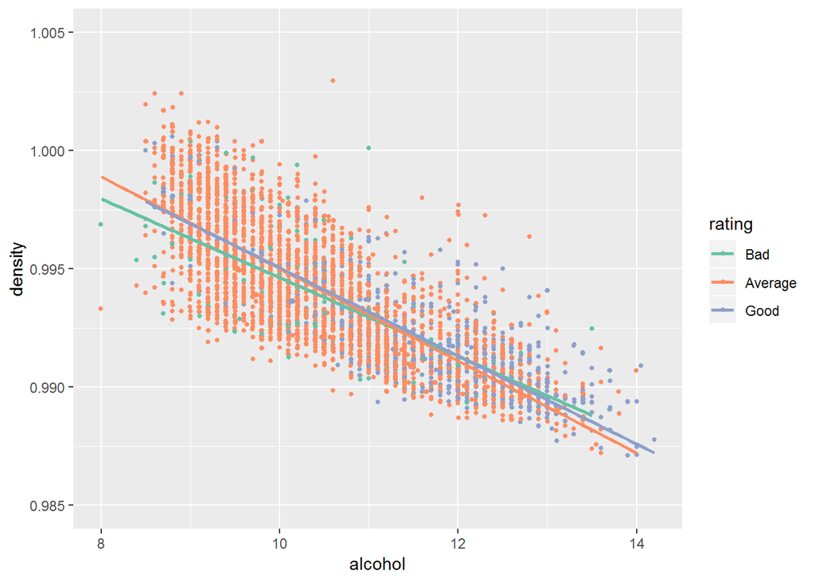

In this plot I can’t really tell a lot, Average **Rating** dots covers most of the plot, And our line is almost the same level, I can see that there are a lot of good **Quality** dots at the end of the tail.

### Total Sulfur Dioxide x Free Sulfur Dioxide x Rating

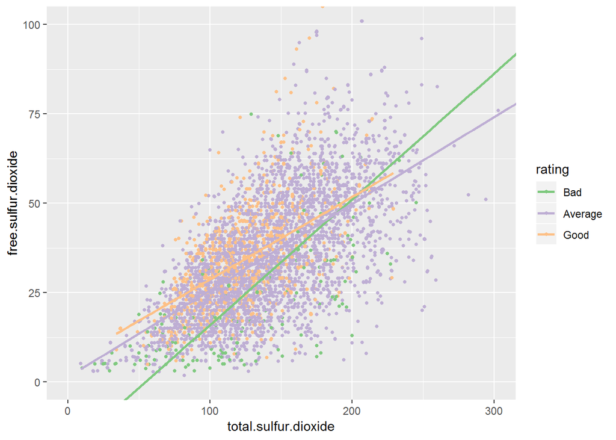

The Average **Rating** in this plot is almost all over the plot, I can see that most of the good **Quality** wine is around 25 to 60 **Free Sulfur Dioxide** and around 75 to 150 **Yotal Sulfur Dioxide**.

### Total Sulfur Dioxide x Density x Rating

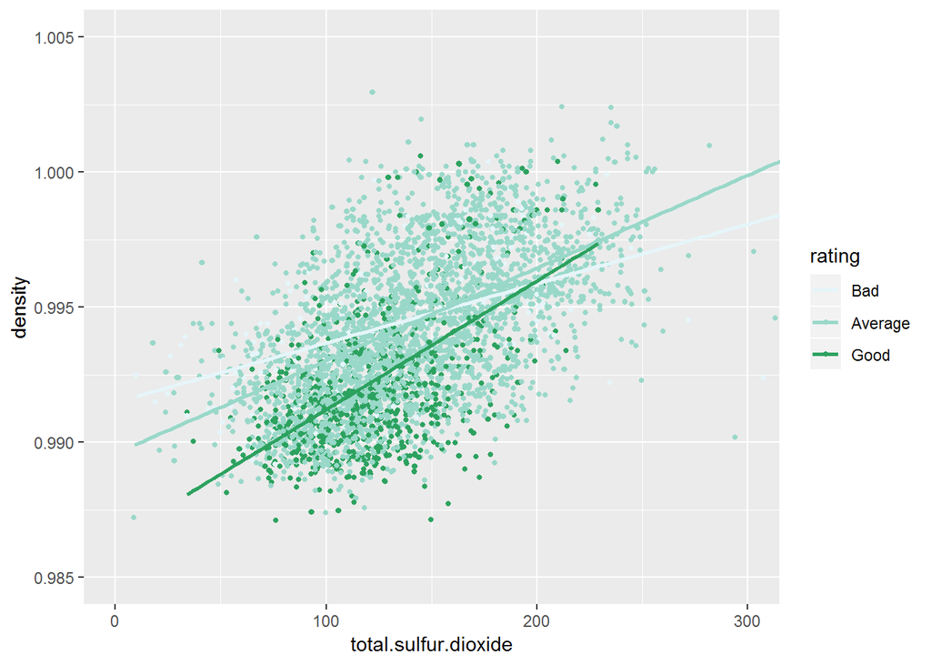

Again, I can observe that having low **Density** might lead to having good **Quality** wines.

### Alcohol x Residual Sugar x Rating

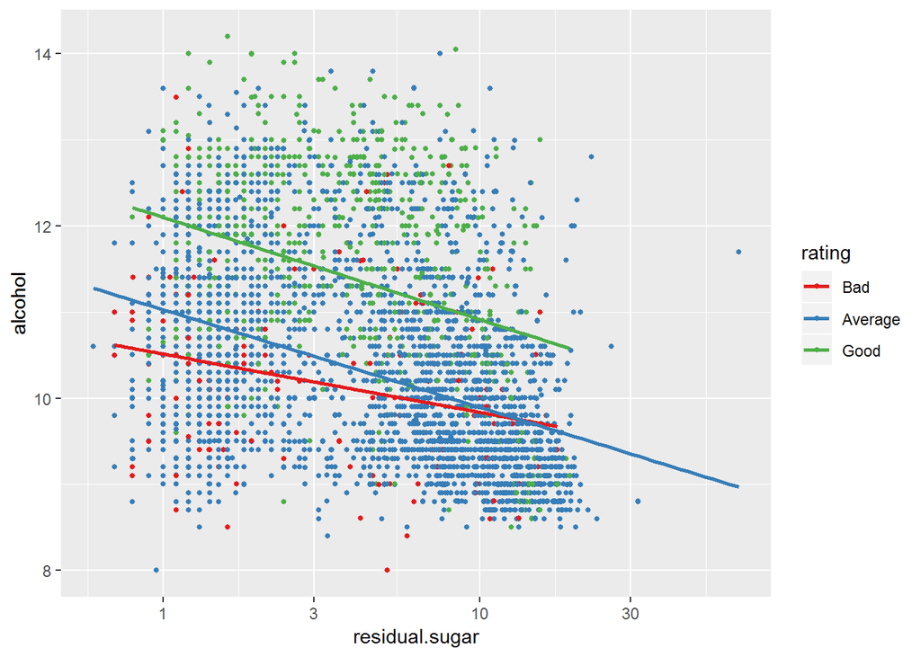

In this plot I can see that most Good **Quality** wine has **Alcohol** more than 11 and it’s showing clearly in this plot.

# Multivariate Analysis

### Talk about some of the relationships you observed in this part of the investigation. Were there features that strengthened each other in terms of looking at your feature(s) of interest?

I Explored the strongest correlations in the dataset with **Rating** of **Quality** of the wine, and i’ve observed that having high **Alcohol** and a good amount of **Residual Sugar** and low **Density** might lead to having a good **Quality** wine.

### Were there any interesting or surprising interactions between features?

I Did not see any surpising interactions.

# Final Plots and Summary

### Plot One

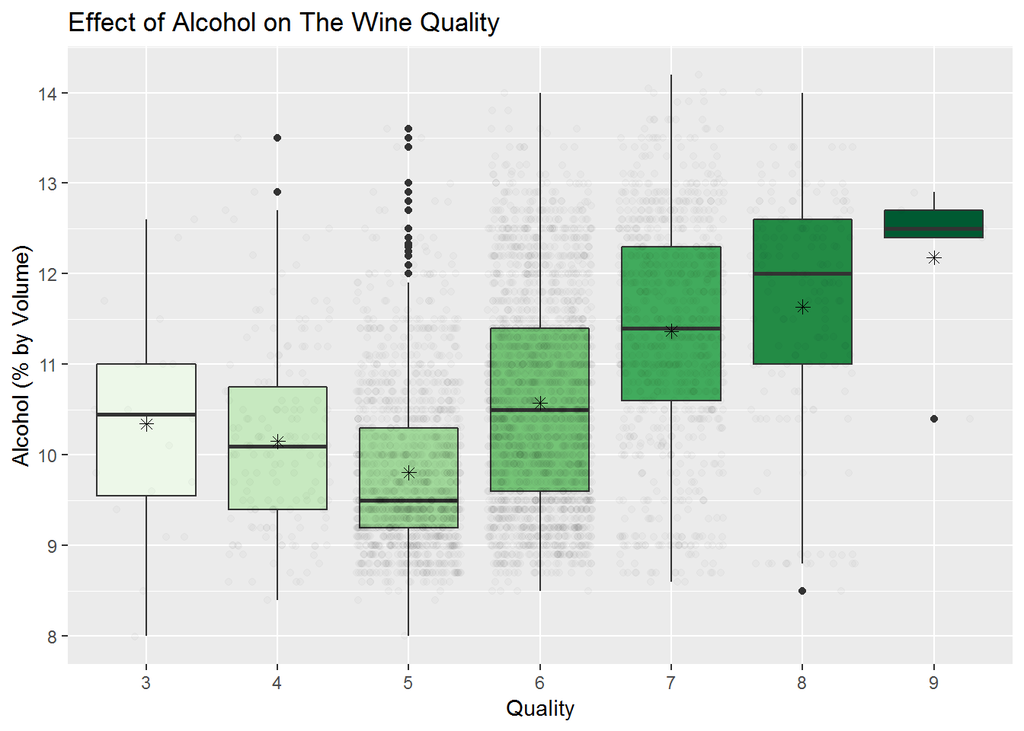

### Plot Two

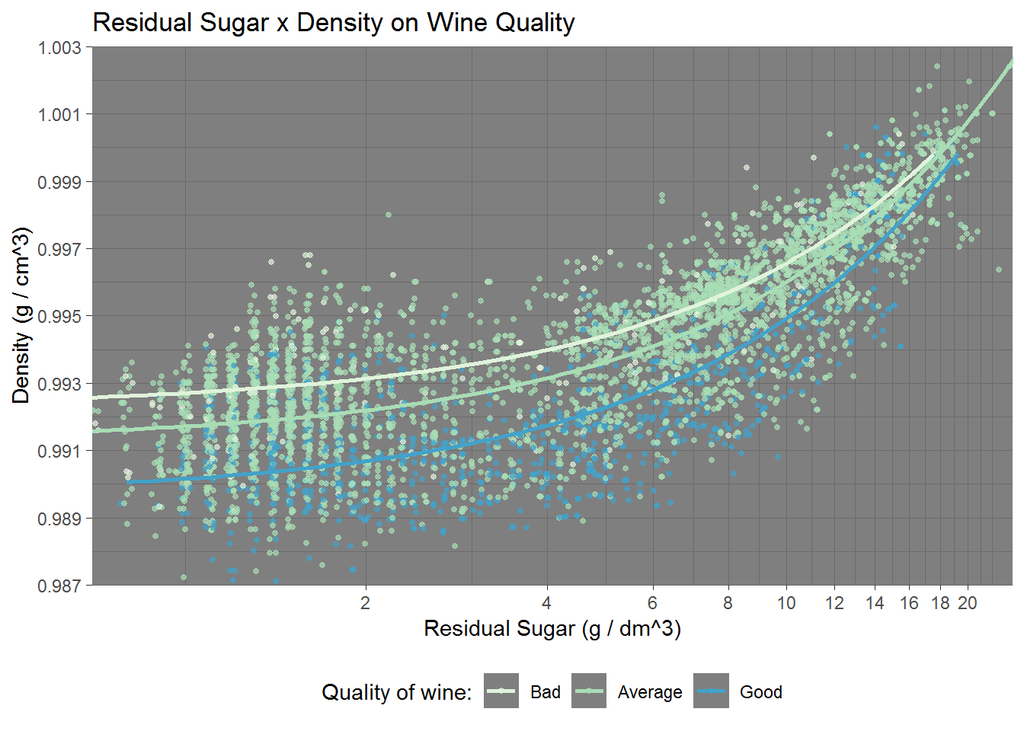

### Description Two

**Density** and **Residual Sugar** has the strongest correlation in our data, And through my analysis it seems that **Residual Sugar** and **Density** also effect the **Quality** of wine, I can see most of good **Quality** wine have a line lower than average and bad wines.

### Plot Three

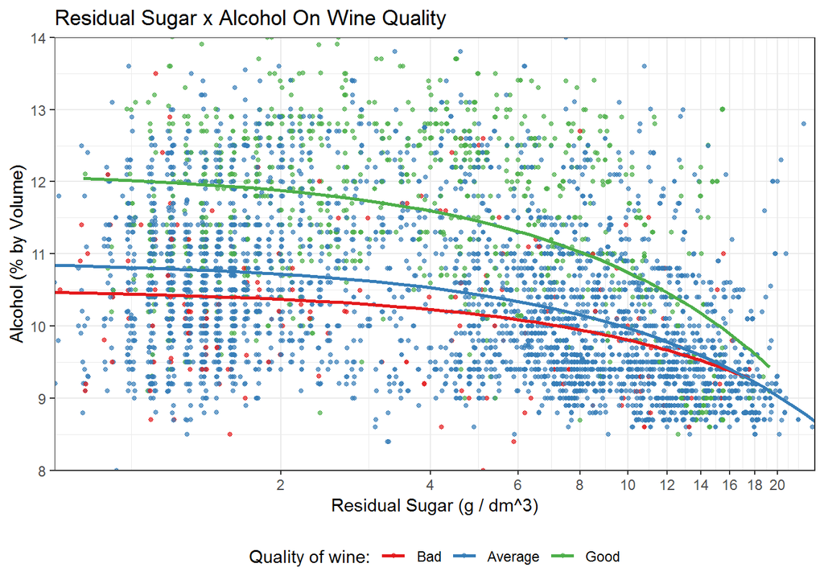

### Description Three

**Alcohol** and **Residual sugar** have a negative correlation, in this plot we can see that we have a lot of good **Quality** wine in the upper area of the plot, and i came to the conclusion that **Alcohol**, **Density** and **Residual Sugar** effect the **Quality** of the wine.

# Reflection

In this project I started with exploring each variable in our dataset, since we only have 12 variables to explore it wasn’t a struggle to look at them, most of the variables have a normal distribution and some are positively skewed, I didn’t observe a lot in the first section, then I started to explore between 2 variables, but before I started, I created a correlation matrix to observe the strongest correlation with **Quality** and other strong correlations, after that i looked at multivariate plots, to explore 2 variables on the **Rating** of wine **Quality**.

My goal was to know which chemical properties affect the **Quality** of wine, the first thing i knew that effect the **Quality** of wine is **Alcohol**, it showed me a clear trend that when **Alcohol** increase the **Quality** and **Rating** of the wine increases as well, also **Residual Sugar** and **Density** showed me that they are a factor as well in affecting the **Quality** of the wine.

One of the things I struggled with is with multivariate plots, it seemed that I didn’t really observe a lot of things and the plots doesn’t seem to show much, one of the things that I can do in the future is using machine learning techniques to predict what could make the perfect wine **Quality**.